# Synopsis

In this report we aim to analyze the impact of severe weather events on public health and economy in the United States during the period 1950 to 2011. Data was obtained from the NOAA Storm database (https://d396qusza40orc.cloudfront.net/repdata%2Fdata%2FStormData.csv.bz2).

To investigate the impact on public health, the total fatalities and total injuries for each severe weather events was analyzed. We find that TORNADOES had the most adverse impact on public health.

To investigate the economic consequences, we compute the total economic damage caused by the severe weather events. The Crop Damage and Property Damage was combined together to get the total damage. We find that FLOODS cause the most economic damage.

# Data Processing

## Read the data

```r
# Include libraries

library (knitr)
```

```r
library(ggplot2)
library(plyr)
ds <- read.csv("repdata-data-StormData.csv.bz2")
```

```r
# Read the file
ds <- read.csv("repdata-data-StormData.csv.bz2")
```

## Explore the data

```r
str(ds)
```

```
## 'data.frame':    902297 obs. of  37 variables:
##  $ STATE__   : num  1 1 1 1 1 1 1 1 1 1 ...
##  $ BGN_DATE  : Factor w/ 16335 levels "1/1/1966 0:00:00",..: 6523 6523 4242 11116 2224 2224 2260 383 3980 3980 ...
##  $ BGN_TIME  : Factor w/ 3608 levels "00:00:00 AM",..: 272 287 2705 1683 2584 3186 242 1683 3186 3186 ...
##  $ TIME_ZONE : Factor w/ 22 levels "ADT","AKS","AST",..: 7 7 7 7 7 7 7 7 7 7 ...
##  $ COUNTY    : num  97 3 57 89 43 77 9 123 125 57 ...
##  $ COUNTYNAME: Factor w/ 29601 levels "","5NM E OF MACKINAC BRIDGE TO PRESQUE ISLE LT MI",..: 13513 1873 4598 10592 4372 10094 1973 23873 24418 4598 ...
##  $ STATE     : Factor w/ 72 levels "AK","AL","AM",..: 2 2 2 2 2 2 2 2 2 2 ...
##  $ EVTYPE    : Factor w/ 985 levels "   HIGH SURF ADVISORY",..: 834 834 834 834 834 834 834 834 834 834 ...
##  $ BGN_RANGE : num  0 0 0 0 0 0 0 0 0 0 ...
##  $ BGN_AZI   : Factor w/ 35 levels "","  N"," NW",..: 1 1 1 1 1 1 1 1 1 1 ...
##  $ BGN_LOCATI: Factor w/ 54429 levels "","- 1 N Albion",..: 1 1 1 1 1 1 1 1 1 1 ...
##  $ END_DATE  : Factor w/ 6663 levels "","1/1/1993 0:00:00",..: 1 1 1 1 1 1 1 1 1 1 ...
##  $ END_TIME  : Factor w/ 3647 levels ""," 0900CST",..: 1 1 1 1 1 1 1 1 1 1 ...
##  $ COUNTY_END: num  0 0 0 0 0 0 0 0 0 0 ...
```

[output cut: 23 more lines]

The columns below are relevant for the analysis required here:

- FATALITIES
- INJURIES
- PROPDMG (USD)
- CROPDMG (USD)
- EVTYPE

The below columns are useful to keep for further analysis:

- BGN_DATE
- END_DATE
- COUNTY
- STATE

This is a total of 9 columns. Dollar value of Property and Crop damage can be totalled into 1 value. This will be our tidy data set with 8 columns.

## Clean the data

The following transformations have been done to tidy the data set

1. Clean-up and re-categorization of the ‘EVTYPE’ field

The ‘EVTYPE’ is a key analysis field here. Let’s check the data in this field

```r
str(table(ds$EVTYPE))
```

```
##  'table' int [1:985(1d)] 1 1 1 1 4 1 1 1 1 4 ...
##  - attr(*, "dimnames")=List of 1
##   ..$ : chr [1:985] "   HIGH SURF ADVISORY" " COASTAL FLOOD" " FLASH FLOOD" " LIGHTNING" ...
```

```r
head(table(ds$EVTYPE), 10)
```

```
##
##    HIGH SURF ADVISORY         COASTAL FLOOD           FLASH FLOOD
##                     1                     1                     1
##             LIGHTNING             TSTM WIND       TSTM WIND (G45)
##                     1                     4                     1
##            WATERSPOUT                  WIND                     ?
##                     1                     1                     1
##       ABNORMAL WARMTH
##                     4
```

The data for ‘EVTYPE’ seems messy. There are a total of 985 EVTYPES in the data and there seems to be repeats / spelling errors.

```r
# Initialize a vector of tidy EVTYPES
f_events <- c("astronom", "avalan", "blizz", "flood", "wind chill", "debris",
    "dense fog", "dense smoke", "drought", "dust devil", "dust", "heat", "frost",
    "funnel", "freezing fog", "hail", "rain", "snow", "surf", "wind", "hurricane",
    "typhoon", "ice storm", "lightning", "marine", "rip current", "seiche",
    "sleet", "storm surge", "thunderstorm", "tornado", "tropical", "tsunami",
    "volcanic", "waterspout", "wildfire", "winter storm", "winter weather")

# Convert the EVTYPES in the data to lower case and remove spaces
x <- ds$EVTYPE
evtypes <- gsub(" ", "", tolower(x))

# Create a new tidy Event Type (EVTYPENEW)
for (i in f_events) evtypes[grepl(i, evtypes)] = i
ds$EVTYPENEW <- evtypes
```

2. Transform the PROPDMG AND CROPDMG to dollar amounts by mapping the respective EXP field

```r
# Map the PROPDMG to $ by mapping the PROPDMGEXP field
ds$PROPDMGEXP <- tolower(ds$PROPDMGEXP)
ds$PROPDMGEXP <- ifelse(ds$PROPDMGEXP == 'h', 100 , ifelse (ds$PROPDMGEXP == 'k', 1000, ifelse(ds$PROPDMGEXP == 'm', 1000000, ifelse(ds$PROPDMGEXP == 'b', 1000000000, 1))))
ds$PROPDMGDOLLAR <- ds$PROPDMG * ds$PROPDMGEXP

# Map the CROPDMG to $ by mapping the CROPDMGEXP field
ds$CROPDMGEXP <- tolower(ds$CROPDMGEXP)
ds$CROPDMGEXP <- ifelse(ds$CROPDMGEXP == 'h', 100 , ifelse (ds$CROPDMGEXP == 'k', 1000, ifelse(ds$CROPDMGEXP == 'm', 1000000, ifelse(ds$CROPDMGEXP == 'b', 1000000000, 1))))
ds$CROPDMGDOLLAR <- ds$CROPDMG * ds$CROPDMGEXP

#Create a new field totalling property and crop damage

ds$TOTDMGDOLLAR <- ds$CROPDMGDOLLAR + ds$PROPDMGDOLLAR
```

3. Other transformations like transforming date fields have been done

```r
# Format the dates as dates
ds$BGN_DATE <- as.Date(ds$BGN_DATE, "%m/%d/%Y")
ds$END_DATE <- as.Date(ds$BGN_DATE, "%m/%d/%Y")
```

And thus an final tidy data set with 8 columns is obtained

```r
# Keep only the 9 relevant columns
ds <- ds [, c("FATALITIES", "INJURIES","TOTDMGDOLLAR", "EVTYPENEW", "BGN_DATE", "END_DATE", "COUNTY", "STATE")]
```

## Exploratory Analysis for Impact on Public Health

First we aggregate the ‘FATALITIES’ and ‘INJURIES’ by ‘EVTYPE’ and check the boxplot of FATALITIES.

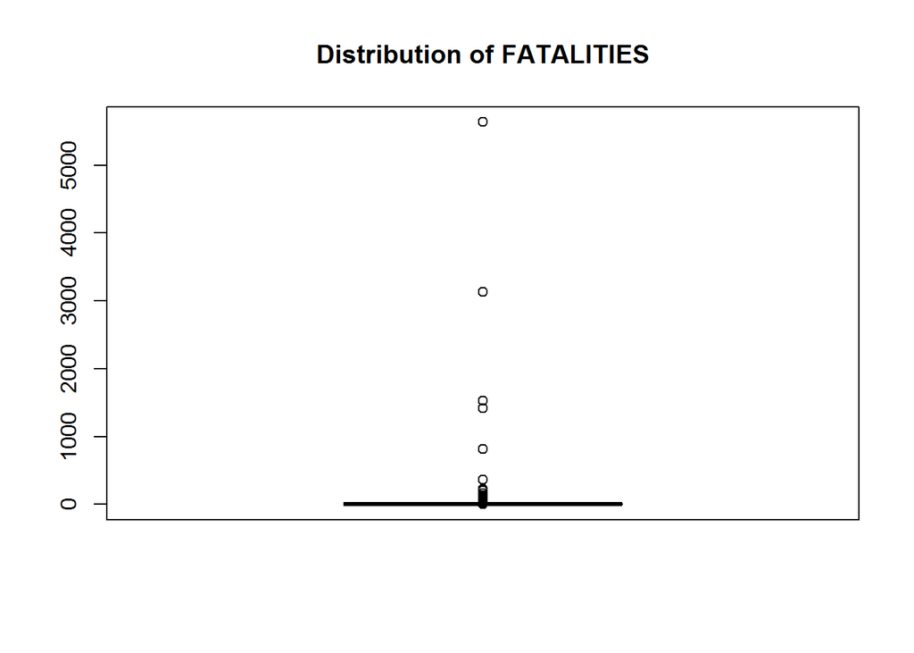

```r
#Aggregate FATALITIES and INJURIES by EVTYPE
dsiph <- aggregate (cbind(FATALITIES, INJURIES)~ EVTYPENEW, FUN=sum, data = ds, na.rm=TRUE)
boxplot (dsiph$FATALITIES, main ="Distribution of FATALITIES")
```

The boxplot for grouping of ‘FATALITIES’ by type of storm event shows concentration in few major event types as causes.

Hence we focus on top 20 event types for fatality and analyze them for impact of public health.

```r
dsiph <- arrange(dsiph, desc(dsiph$FATALITIES))
n <-20
dsiph2 <- dsiph[1:n,]
```

The proportion of FATALITIES and INJURIES covered by this smaller data set is close to 95%.

FATALITIES - 0.9708815 INJURIES - 0.9786662

This gives us confidence that the smaller data set is representative as far as impact on public health is concerned.

## Exploratory Analysis for Economic Consequences

First we aggregate the ‘TOTALDOLLARDMG’ by ‘EVTYPE’

```r
dsec <- aggregate (TOTDMGDOLLAR ~ EVTYPENEW, FUN=sum, data = ds, na.rm=TRUE)
```

We focus on top 20 event types for dollar damage and analyze them.

```r
dsec <- arrange(dsec, desc(dsec$TOTDMGDOLLAR))
n <-20
dsec2 <- dsec[1:n,]
```

# Results

## Impact on Population Health

### Distribution of FATALITIES by Event Type

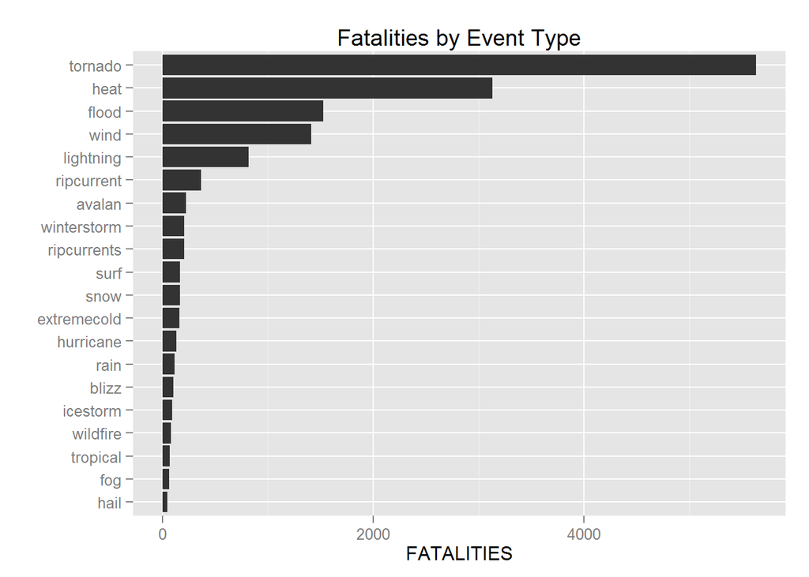

```r
ggplot(data=dsiph2, aes(x=reorder(EVTYPENEW, FATALITIES), y=FATALITIES)) + geom_bar(stat="identity") + coord_flip() + xlab("") + ggtitle("Fatalities by Event Type")
```

### Distribution of INJURIES by Event Type

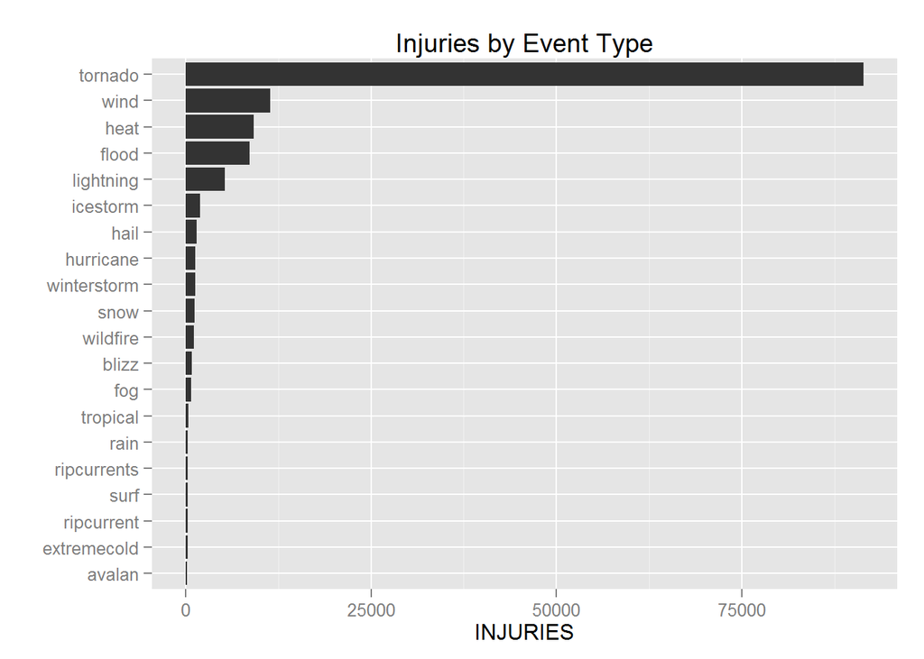

```r
ggplot(data=dsiph2, aes(x=reorder(EVTYPENEW, INJURIES), y=INJURIES)) + geom_bar(stat="identity") + coord_flip() + xlab("") + ggtitle("Injuries by Event Type")
```

Hence we can conclude that Tornadoes cause the most impact on population health among Storm Events.

## Adverse Economic Consequences

### Distribution of economic consequences by Event Type

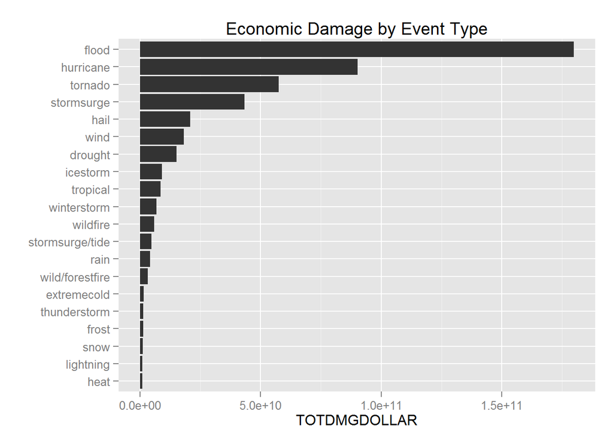

```r
ggplot(data=dsec2, aes(x=reorder(EVTYPENEW, TOTDMGDOLLAR), y=TOTDMGDOLLAR)) + geom_bar(stat="identity") + coord_flip() + xlab("") + ggtitle("Economic Damage by Event Type")
```

Hence we can conclude that Floods cause the most economic damage among Storm Events.